# Portfólio Data Science

Lennon V. Alves Dias

08/10/2019

Este portfólio tem como objetivo demonstrar conhecimentos abrangentes sobre análise e interpretação dos dados.

## Base de Dados

Como base de dados do portfólio, utilizarei a base do jogo FIFA 18 obtida através do site [Programando IA com R](https://sites.google.com/usp.br/programando-ia-com-r/base-de-conhecimento/datasets-usados-em-aula?authuser=0).

A base está em formato `csv` e, para as análises realizadas neste portfólio será necessário realizar a leitura deste arquivo.

```r
fifa18 <- read.csv(file=".\\fifa18.csv", header=TRUE, sep=",")
```

Como forma de conhecer os dados, podemos realizar o comando `dim`, que nos retorna a dimensão do objeto:

```r
dim(fifa18)
```

```
## [1] 17994   185
```

e `colnames` que lista as colunas do *dataframe*:

```r
colnames(fifa18)
```

```
##   [1] "ID"
##   [2] "name"
##   [3] "full_name"
##   [4] "club"
##   [5] "club_logo"
##   [6] "special"
##   [7] "age"
##   [8] "league"
##   [9] "birth_date"
##  [10] "height_cm"
##  [11] "weight_kg"
##  [12] "body_type"
##  [13] "real_face"
##  [14] "flag"
##  [15] "nationality"
```

[output cut: 170 more lines]

Para facilitar a visualização, vamos nos limitar à utilizar apenas as colunas: `name`, `club`, `league`, `nationality`, `eur_value`, `eur_wage`, `eur_release_clause`, `overall` e `gk`.

Baseado nestas colunas, vamos analisar os 5 principais jogadores pelo nível geral, e também separados por jogador de linha e goleiros. Uma outra análise será baseado nos jogadores com maior valor de mercado, maiores salários e maiores valores de rescisão.

```r
minififa18 <- subset(fifa18, select = c("name", "club", "league", "nationality", "eur_value", "eur_wage", "eur_release_clause", "overall", "gk"))
```

Listando as colunas do novo *dataframe*:

```r
colnames(minififa18)
```

```
## [1] "name"               "club"               "league"
## [4] "nationality"        "eur_value"          "eur_wage"
## [7] "eur_release_clause" "overall"            "gk"
```

Para conhecer melhor os dados do *dataframe* pode utilizar o comando `summary` que apresenta o resumo dos resultados.

```r
summary(minififa18)
```

```
##            name                       club
##  J. Rodríguez:    7                     :  253
##  J. Valencia :    7   Amiens SC Football:   33
##  J. Williams :    7   Arsenal           :   33
##  D. González :    6   AS Monaco         :   33
##  Felipe      :    6   Borussia Dortmund :   33
##  J. Jones    :    6   Bournemouth       :   33
##  (Other)     :17955   (Other)           :17576
##                       league         nationality      eur_value
##  Argentinian Superliga   :  780   England  : 1631   Min.   :        0
##  English Championship    :  717   Germany  : 1147   1st Qu.:   300000
##  English League One      :  668   Spain    : 1020   Median :   700000
##  English Premier League  :  654   France   :  966   Mean   :  2370511
##  Spanish Segunda División:  637   Argentina:  962   3rd Qu.:  2000000
##  English League Two      :  633   Brazil   :  806   Max.   :123000000
##  (Other)                 :13905   (Other)  :11462
##     eur_wage      eur_release_clause     overall            gk
##  Min.   :     0   Min.   :    13000   Min.   :46.00   Min.   :46.00
##  1st Qu.:  2000   1st Qu.:   528000   1st Qu.:62.00   1st Qu.:59.00
##  Median :  4000   Median :  1200000   Median :66.00   Median :65.00
##  Mean   : 11504   Mean   :  4449111   Mean   :66.25   Mean   :64.71
##  3rd Qu.: 12000   3rd Qu.:  3600000   3rd Qu.:71.00   3rd Qu.:70.00
##  Max.   :565000   Max.   :236800000   Max.   :94.00   Max.   :92.00
##                   NA's   :1494                        NA's   :15973
```

Para a análise dos jogadores com maiores *overall*, primeiro podemos ordenar a propriedade em ordem decrescente:

```r
df <-minififa18[order(-minififa18$overall),]
head(df, 10)
```

```
##                 name                club                   league
## 1  Cristiano Ronaldo      Real Madrid CF Spanish Primera División
## 2           L. Messi        FC Barcelona Spanish Primera División
## 3             Neymar Paris Saint-Germain           French Ligue 1
## 4          L. Suárez        FC Barcelona Spanish Primera División
## 5           M. Neuer    FC Bayern Munich        German Bundesliga
## 6     R. Lewandowski    FC Bayern Munich        German Bundesliga
## 7             De Gea   Manchester United   English Premier League
## 8          E. Hazard             Chelsea   English Premier League
## 9           T. Kroos      Real Madrid CF Spanish Primera División
## 10        G. Higuaín            Juventus          Italian Serie A
##    nationality eur_value eur_wage eur_release_clause overall gk
## 1     Portugal  9.55e+07   565000          195800000      94 NA
## 2    Argentina  1.05e+08   565000          215300000      93 NA
## 3       Brazil  1.23e+08   280000          236800000      92 NA
## 4      Uruguay  9.70e+07   510000          198900000      92 NA
## 5      Germany  6.10e+07   230000          100700000      92 92
## 6       Poland  9.20e+07   355000          151800000      91 NA
## 7        Spain  6.45e+07   215000          124200000      90 90
## 8      Belgium  9.05e+07   295000          174200000      90 NA
## 9      Germany  7.90e+07   340000          162000000      90 NA
## 10   Argentina  7.70e+07   275000          127100000      90 NA
```

E então apresentar o gráfico com os 5 maiores valores de pontuação geral:

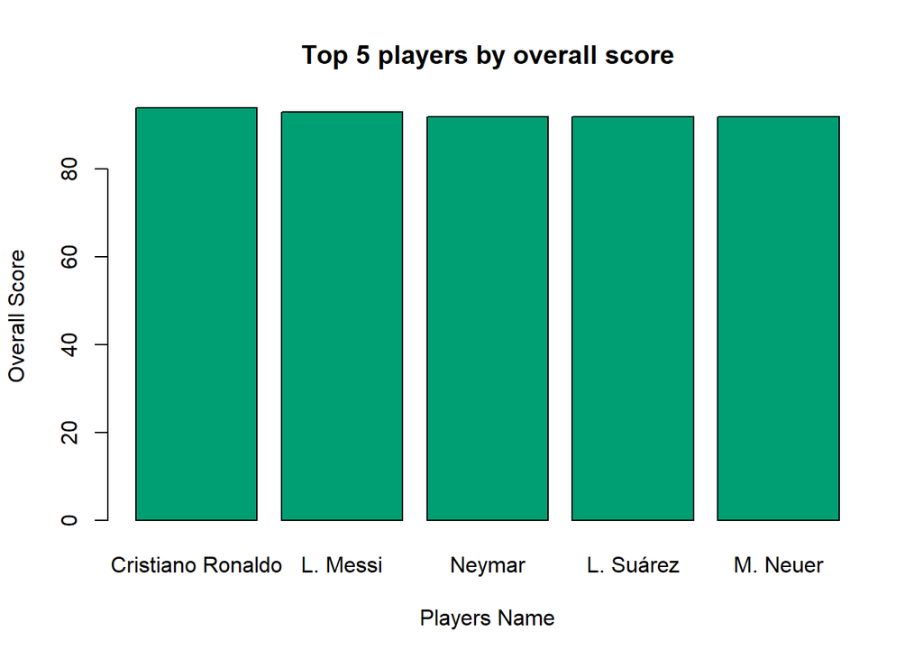

```r
barplot(head(df, 5)$overall,names.arg=head(df, 5)$name, xlab="Players Name", ylab="Overall Score", col="#009E73", main="Top 5 players by overall score")
```

Podemos também, utilizar o pacote [`GGPLOT2`](https://ggplot2.tidyverse.org/) para visualizar a comparação dos valores entre os *players* do jogo. Esta biblioteca fornece uma gama de possibilidades de plotagem de gráficos.

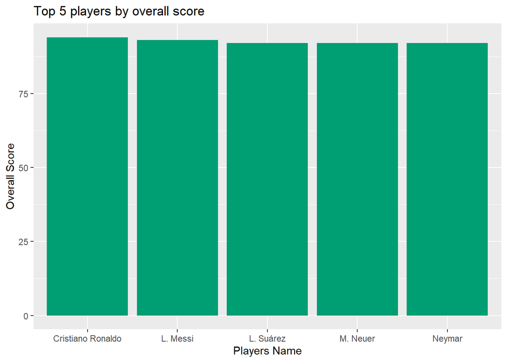

```r
library(ggplot2)

ggplot(data=head(df, 5), aes(x=name, y=overall)) + geom_bar(stat="identity", fill="#009E73") + labs(x="Players Name", y="Overall Score", title="Top 5 players by overall score")
```

Após essa análise geral, vamos separar pelos jogadores de linha. Para realizar a operação de `filter` utilizando o operador de pipe `%>%`, vamos importar a lib `dplyr`.

```r
library(dplyr)
```

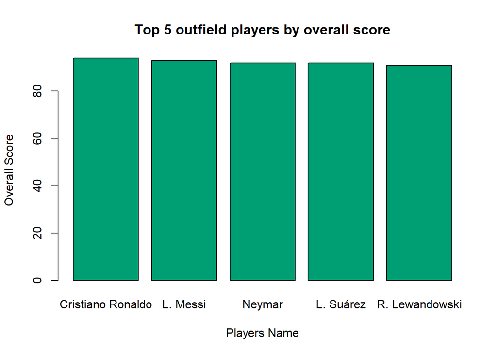

```r
df_filter = head(df %>% filter(is.na(gk)), 5)
barplot(df_filter$overall,names.arg=df_filter$name, xlab="Players Name", ylab="Overall Score", col="#009E73", main="Top 5 outfield players by overall score")
```

Para a plotagem acima, utilizamos a função `is.na` para identificar os valores com `NA` dentro da coluna `gk`. Para análise dos goleiros, iremos realizar o filtro oposto, aplicando `!is.na()`.

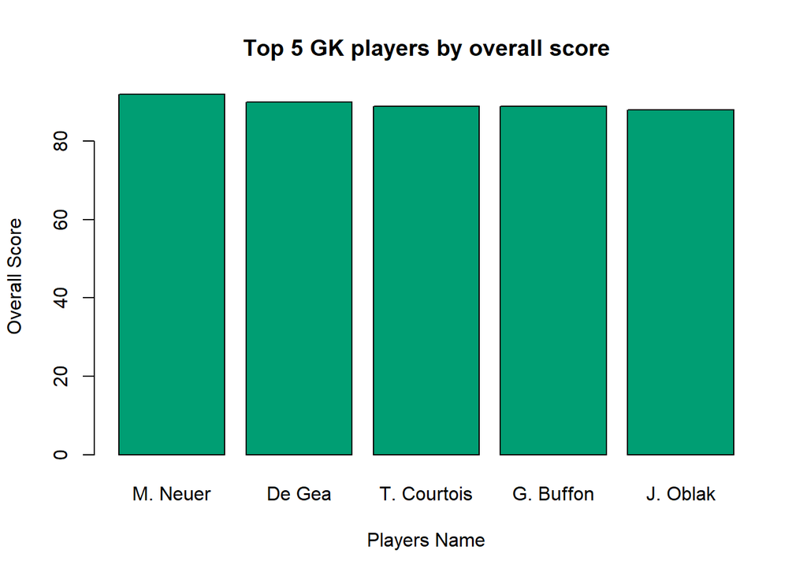

```r
df_filter = head(df %>% filter(!is.na(gk)), 5)
barplot(df_filter$overall,names.arg=df_filter$name, xlab="Players Name", ylab="Overall Score", col="#009E73", main="Top 5 GK players by overall score")
```

Seguindo o mesmo conhecimento aplicado acima, podemos plotar a análise contendo os maiores valores de mercado entre os jogadores.

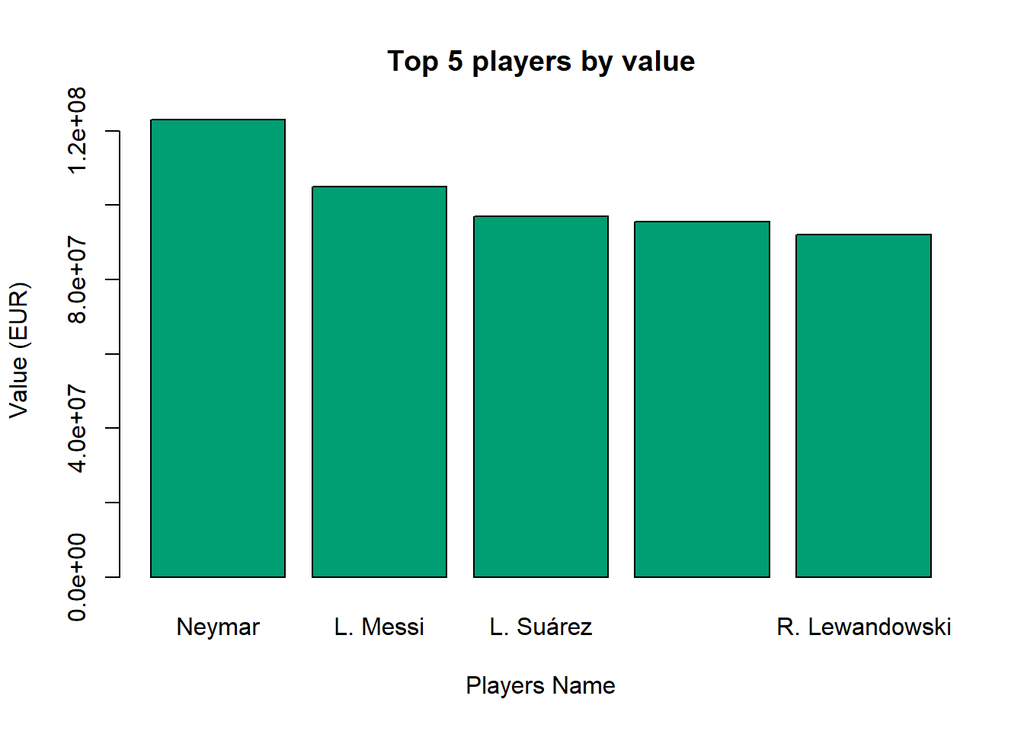

```r
df <- minififa18[order(-minififa18$eur_value),]
barplot(head(df, 5)$eur_value,names.arg=head(df, 5)$name, xlab="Players Name", ylab="Value (EUR)", col="#009E73", main="Top 5 players by value")
```

Os maiores salários.

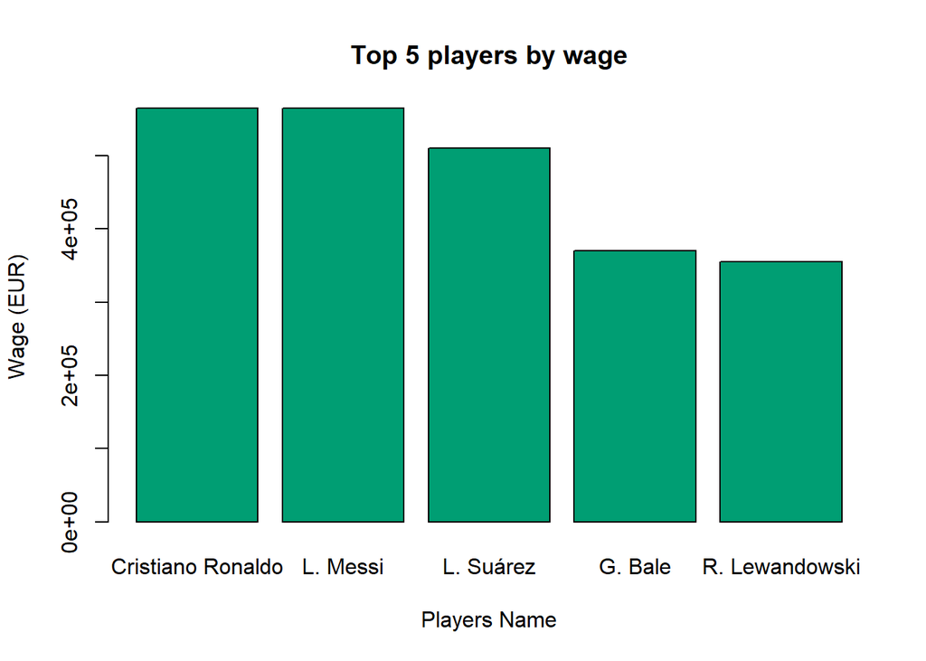

```r
df <- minififa18[order(-minififa18$eur_wage),]
barplot(head(df, 5)$eur_wage,names.arg=head(df, 5)$name, xlab="Players Name", ylab="Wage (EUR)", col="#009E73", main="Top 5 players by wage")
```

E os maiores valores nos contratos de rescisão.

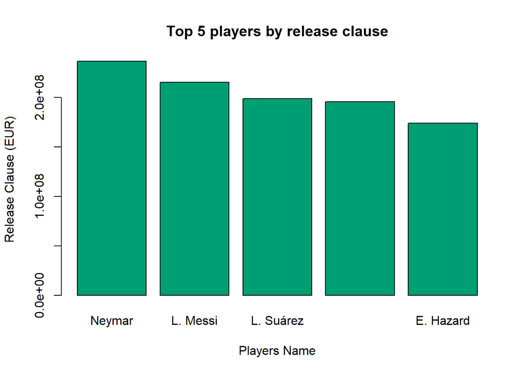

```r
df <- minififa18[order(-minififa18$eur_release_clause),]
barplot(head(df, 5)$eur_release_clause,names.arg=head(df, 5)$name, xlab="Players Name", ylab="Release Clause (EUR)", col="#009E73", main="Top 5 players by release clause")
```

*Este portfólio será continuado.*

[lennon.cloud](https://lennon.cloud/)